# Traffic Sign Classification using CNN

## Step 0: Load The Data

```python
# Load pickled data
import pickle
import numpy as np

# Load the training, validation, and test files
training_file = "traffic-signs-data/train.p"
validation_file = "traffic-signs-data/valid.p"
testing_file = "traffic-signs-data/test.p"

with open(training_file, mode='rb') as f:
    train = pickle.load(f)
with open(validation_file, mode='rb') as f:
    valid = pickle.load(f)
with open(testing_file, mode='rb') as f:
    test = pickle.load(f)

X_train, y_train = np.float32(train['features']), train['labels']
X_valid, y_valid = np.float32(valid['features']), valid['labels']
X_test, y_test = np.float32(test['features']), test['labels']
```

## Step 1: Dataset Summary & Exploration

The pickled data is a dictionary with 4 key/value pairs:

- `'features'` is a 4D array containing raw pixel data of the traffic sign images, (num examples, width, height, channels).
- `'labels'` is a 1D array containing the label/class id of the traffic sign. The file `signnames.csv` contains id -> name mappings for each id.
- `'sizes'` is a list containing tuples, (width, height) representing the original width and height the image.
- `'coords'` is a list containing tuples, (x1, y1, x2, y2) representing coordinates of a bounding box around the sign in the image. **THESE COORDINATES ASSUME THE ORIGINAL IMAGE. THE PICKLED DATA CONTAINS RESIZED VERSIONS (32 by 32) OF THESE IMAGES**

### Basic Summary of the Data Set/ Exploratory visualization of the dataset

```
Number of training examples = 34799
```

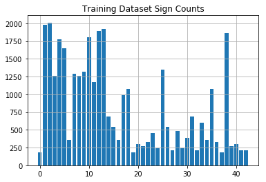

```
Number of validation examples = 4410
```

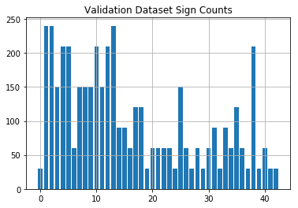

```
Number of testing examples = 12630
```

[figure not shown]

```
Image data shape = (32, 32)
Number of classes = 43
```

```python
### Use python, pandas or numpy methods rather than hard coding the results
import matplotlib.pyplot as plt

# Number of training examples
n_train = X_train.shape[0]
print("Number of training examples =", n_train)
unique, counts = np.unique(y_train, return_counts=True)
plt.bar(unique, counts)
plt.grid()
plt.title("Training Dataset Sign Counts")
plt.show()

# Number of validation examples
n_validation = X_valid.shape[0]
print("Number of validation examples =", n_validation)
unique, counts = np.unique(y_valid, return_counts=True)
plt.bar(unique, counts)
plt.grid()
plt.title("Validation Dataset Sign Counts")
plt.show()

# Number of testing examples.
n_test = X_test.shape[0]
print("Number of testing examples =", n_test)
unique, counts = np.unique(y_valid, return_counts=True)
plt.bar(unique, counts)
plt.grid()
plt.title("Testing Dataset Sign Counts")
plt.show()

# What's the shape of an traffic sign image?
image_shape = (X_test[0, 1].shape[0], X_test[0, 2].shape[0])
print("Image data shape =", image_shape)

# How many unique classes/labels there are in the dataset.
n_classes = len(set(y_train))
print("Number of classes =", n_classes)
```

### Get the readable description of Traffic Sign Labels

```python
import sys
import csv
#define user input as variable
label_map_file = 'signnames.csv'

def get_label_description(label):
    # read csv file into "label_map"
    label_map = csv.DictReader(open(label_map_file), delimiter = ',')
    # read each row in "label_map"
    for row in label_map:
        if(row['ClassId'] == str(label)):
            return(row['SignName'])
```

### Display few random Traffic Signs for each class and its descriptions

```
Speed limit (20km/h) (Label: 0)
```

[figure not shown]

```
Speed limit (30km/h) (Label: 1)
```

[figure not shown]

```
Speed limit (50km/h) (Label: 2)
```

[figure not shown]

```
Speed limit (60km/h) (Label: 3)
```

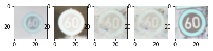

```
Speed limit (70km/h) (Label: 4)
```

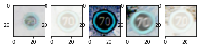

```
Speed limit (80km/h) (Label: 5)
```

[figure not shown]

```
End of speed limit (80km/h) (Label: 6)
```

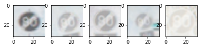

```
Speed limit (100km/h) (Label: 7)
```

[figure not shown]

```
Speed limit (120km/h) (Label: 8)
```

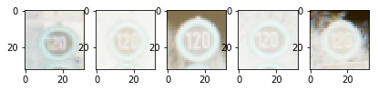

```
No passing (Label: 9)
```

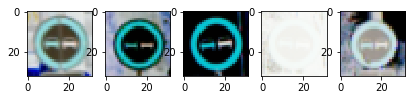

```
No passing for vehicles over 3.5 metric tons (Label: 10)
```

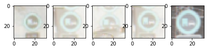

```
Right-of-way at the next intersection (Label: 11)
```

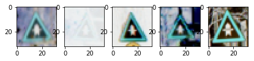

```
Priority road (Label: 12)
```

[31 more figures not shown]

```python
### Data exploration visualization code goes here.
from random import randrange
# Visualizations will be shown in the notebook.
%matplotlib inline

# Number of Signs to randomly pick and display (< 6)
num_of_signs = 5
for c in range(43):  # Iterate all classes
    idx = np.where(y_train == c)  # Find index for class
    train_img = X_train[np.random.choice(idx[0], num_of_signs)]  # Pick ten images to display
    label_desc = get_label_description(c)

    print(label_desc + ' (Label: ' + str(int(c)) + ')')
    plt.figure(c)
    for i in range(num_of_signs):
        plt.subplot(1, num_of_signs, i+1);
        plt.imshow(train_img[i])
        plt.subplots_adjust(right=1)

    plt.show()
```

## Step 2: Design and Test a Model Architecture

Design and implement a deep learning model that learns to recognize traffic signs. The model was trained and tested on the [German Traffic Sign Dataset](http://benchmark.ini.rub.de/?section=gtsrb&subsection=dataset).

### Pre-process the Data Set

Minimally, the image data should be normalized so that the data has mean zero and equal variance. For image data, `(pixel - 128)/ 128` is a quick way to approximately normalize the data and can be used in this project.

```python
### Preprocess the data here. It is required to normalize the data. Other preprocessing steps could include
### converting to grayscale, etc.
from sklearn.utils import shuffle
import math
import cv2

def preprocessAndNormalize(rgb):
    yuv = np.empty(rgb.shape)
    # Change the RGB colorspace to YUV
    for i in range(0, rgb.shape[0]):
        yuv[i] = cv2.cvtColor(rgb[i], cv2.COLOR_RGB2YUV)

    # Normalize the YUV data
    yuv[:,:,:, 0] = (yuv[:,:,:, 0] - 128.0)/128.0 #Y range: 0 to 255
    yuv[:,:,:, 1] = (yuv[:,:,:, 1])/128.0 #U range: -128 to 127
    yuv[:,:,:, 2] = (yuv[:,:,:, 2])/128.0 #V range: -128 to 127
    return yuv
```

### Preprocess and Normalize training, validation, and test data

```python
# training data
X_train = preprocessAndNormalize(X_train)

# validation data
X_valid = preprocessAndNormalize(X_valid)

# training data
X_test = preprocessAndNormalize(X_test)
```

### Model Architecture

```python
### Define your architecture here.
import tensorflow as tf

EPOCHS = 30
BATCH_SIZE = 128

rate = 0.00075
accuracy_thres = 0.94
```

# Train, Validate and Test the Model

A validation set can be used to assess how well the model is performing. A low accuracy on the training and validation sets imply underfitting. A high accuracy on the training set but low accuracy on the validation set implies overfitting.

### Create the Model

```python
### Train your model here.
### Calculate and report the accuracy on the training and validation set.
from tensorflow.contrib.layers import flatten

def ConvNet(x):
    # Arguments used for tf.truncated_normal, randomly defines variables for the weights and biases for each layer
    mu = 0
    sigma = 0.1

    # SOLUTION: Layer 1: Convolutional. Input = 32x32x3. Output = 28x28x16.
    conv1_W = tf.Variable(tf.truncated_normal(shape=(5, 5, 3, 16), mean = mu, stddev = sigma))
    conv1_b = tf.Variable(tf.zeros(16))
    conv1   = tf.nn.conv2d(x, conv1_W, strides=[1, 1, 1, 1], padding='VALID') + conv1_b

    # SOLUTION: Activation.
    conv1 = tf.nn.relu(conv1)

    # SOLUTION: Pooling. Input = 28x28x16. Output = 14x14x16.
    conv1 = tf.nn.max_pool(conv1, ksize=[1, 2, 2, 1], strides=[1, 2, 2, 1], padding='VALID')

    # SOLUTION: Layer 2: Convolutional. Output = 10x10x32.
    conv2_W = tf.Variable(tf.truncated_normal(shape=(5, 5, 16, 32), mean = mu, stddev = sigma))
    conv2_b = tf.Variable(tf.zeros(32))
    conv2   = tf.nn.conv2d(conv1, conv2_W, strides=[1, 1, 1, 1], padding='VALID') + conv2_b

    # SOLUTION: Activation.
    conv2 = tf.nn.relu(conv2)

    # SOLUTION: Pooling. Input = 10x10x32. Output = 5x5x32.
    conv2 = tf.nn.max_pool(conv2, ksize=[1, 2, 2, 1], strides=[1, 2, 2, 1], padding='VALID')

    # SOLUTION: Layer 3: Convolutional. Output = 5x5x64.
    conv3_W = tf.Variable(tf.truncated_normal(shape=(1, 1, 32, 64), mean = mu, stddev = sigma))
    conv3_b = tf.Variable(tf.zeros(64))
    conv3   = tf.nn.conv2d(conv2, conv3_W, strides=[1, 1, 1, 1], padding='VALID') + conv3_b

    # SOLUTION: Activation.
    conv3 = tf.nn.relu(conv3)

    # SOLUTION: Pooling. Input = 5x5x64. Output = 5x5x64.
    conv3 = tf.nn.max_pool(conv3, ksize=[1, 2, 2, 1], strides=[1, 1, 1, 1], padding='SAME')

    # SOLUTION: Flatten. Input = 5x5x64. Output = 1600 + 800 (flattened conv3 layer concatenated with flattened conv2 layer).
    fc0   = tf.concat([flatten(conv3), flatten(conv2)], axis=1)

    # SOLUTION: Layer 4: Fully Connected. Input = 1600+800. Output = 512.
    fc1_W = tf.Variable(tf.truncated_normal(shape=(2400, 512), mean = mu, stddev = sigma))
    fc1_b = tf.Variable(tf.zeros(512))
    fc1   = tf.matmul(fc0, fc1_W) + fc1_b

    # SOLUTION: Activation.
    fc1    = tf.nn.relu(fc1)
    # Dropout Regularization
    fc1 = tf.nn.dropout(fc1, keep_prob = 0.4)

    # SOLUTION: Layer 5: Fully Connected. Input = 512. Output = 84.
    fc2_W  = tf.Variable(tf.truncated_normal(shape=(512, 84), mean = mu, stddev = sigma))
    fc2_b  = tf.Variable(tf.zeros(84))
    fc2    = tf.matmul(fc1, fc2_W) + fc2_b

    # SOLUTION: Activation.
    fc2    = tf.nn.relu(fc2)
    # Dropout Regularization
    fc1 = tf.nn.dropout(fc1, keep_prob = 0.4)

    # SOLUTION: Layer 6: Fully Connected. Input = 84. Output = 43.
    fc3_W  = tf.Variable(tf.truncated_normal(shape=(84, 43), mean = mu, stddev = sigma))
    fc3_b  = tf.Variable(tf.zeros(43))
    logits = tf.matmul(fc2, fc3_W) + fc3_b

    # Create a Network parameter dict for visualization
    global network_params
    network_params = {
        "conv1": conv1,
        "conv2": conv2,
        "conv3": conv3,
        "fc0": fc0,
        "fc1": fc1,
        "fc2": fc2,
        "logits": logits
    }

    return logits

x = tf.placeholder(tf.float32, (None, 32, 32, 3))
y = tf.placeholder(tf.int32, (None))
one_hot_y = tf.one_hot(y, 43)

logits = ConvNet(x)
cross_entropy = tf.nn.softmax_cross_entropy_with_logits(labels=one_hot_y, logits=logits)
loss_operation = tf.reduce_mean(cross_entropy)
optimizer = tf.train.AdamOptimizer(learning_rate = rate)
training_operation = optimizer.minimize(loss_operation)

correct_prediction = tf.equal(tf.argmax(logits, 1), tf.argmax(one_hot_y, 1))
accuracy_operation = tf.reduce_mean(tf.cast(correct_prediction, tf.float32))
saver = tf.train.Saver()
```

### Evaluate Function

```python
def evaluate(X_data, y_data):
    num_examples = len(X_data)
    total_accuracy = 0
    sess = tf.get_default_session()
    for offset in range(0, num_examples, BATCH_SIZE):
        batch_x, batch_y = X_data[offset:offset+BATCH_SIZE], y_data[offset:offset+BATCH_SIZE]
        accuracy = sess.run(accuracy_operation, feed_dict={x: batch_x, y: batch_y})
        total_accuracy += (accuracy * len(batch_x))
    return total_accuracy / num_examples
```

### Tensorflow Training and Validation Session

Train and validate the model here and save the session so that it can be retrieved later to test its performance

```python
with tf.Session() as sess:
    sess.run(tf.global_variables_initializer())
    num_examples = n_train

    training_accuracy = np.float64(np.empty(EPOCHS))
    validation_accuracy = np.float64(np.empty(EPOCHS))

    print("Training...")
    print()
    for i in range(EPOCHS):
        X_train, y_train = shuffle(X_train, y_train)
        for offset in range(0, num_examples, BATCH_SIZE):
            end = offset + BATCH_SIZE
            batch_x, batch_y = X_train[offset:end], y_train[offset:end]
            sess.run(training_operation, feed_dict={x: batch_x, y: batch_y})

        training_accuracy[i] = evaluate(X_train, y_train)
        validation_accuracy[i] = evaluate(X_valid, y_valid)
        print("EPOCH {} ...".format(i+1))
        print("Training Accuracy = {:.3f}%".format(training_accuracy[i]*100))
        print("Validation Accuracy = {:.3f}%".format(validation_accuracy[i]*100))

        # Early termination to avoid overfitting
        if (validation_accuracy[i] >= accuracy_thres):
            EPOCHS = i+1
            break

    saver.save(sess, './saved_sess/traffic_sign_lenet')
    print("Model saved")
```

```
Training...

EPOCH 1 ...
Training Accuracy = 79.134%
Validation Accuracy = 72.698%
EPOCH 2 ...
Training Accuracy = 92.859%
Validation Accuracy = 86.576%
EPOCH 3 ...
Training Accuracy = 95.566%
Validation Accuracy = 88.776%
EPOCH 4 ...
Training Accuracy = 97.356%
Validation Accuracy = 90.952%
EPOCH 5 ...
Training Accuracy = 97.664%
Validation Accuracy = 91.542%
EPOCH 6 ...
Training Accuracy = 98.474%
Validation Accuracy = 92.358%
EPOCH 7 ...
Training Accuracy = 98.517%
Validation Accuracy = 92.676%
EPOCH 8 ...
Training Accuracy = 98.988%
Validation Accuracy = 92.789%
EPOCH 9 ...
Training Accuracy = 99.126%
Validation Accuracy = 93.605%
EPOCH 10 ...
Training Accuracy = 98.845%
Validation Accuracy = 93.243%
EPOCH 11 ...
Training Accuracy = 99.103%
Validation Accuracy = 92.426%
EPOCH 12 ...
Training Accuracy = 99.368%
Validation Accuracy = 93.855%
EPOCH 13 ...
Training Accuracy = 99.172%
Validation Accuracy = 93.197%
EPOCH 14 ...
Training Accuracy = 99.491%
Validation Accuracy = 94.399%
Model saved
```

### Plot the Training and Validation Accuracy

```
INFO:tensorflow:Restoring parameters from ./saved_sess/traffic_sign_lenet
```

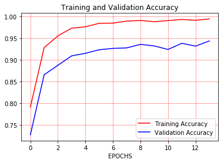

```python
# Load the saved model
with tf.Session() as sess:
    saver.restore(sess, './saved_sess/traffic_sign_lenet')
    plt.figure
    train_plot = plt.plot(range(EPOCHS), training_accuracy[range(EPOCHS)], 'r-', label='Training Accuracy')
    valid_plot = plt.plot(range(EPOCHS), validation_accuracy[range(EPOCHS)], 'b-', label='Validation Accuracy')
    plt.legend()
    plt.title("Training and Validation Accuracy")
    plt.xlabel("EPOCHS")
    plt.grid(color='r', linestyle='--', linewidth=0.5);
    plt.show()
```

## Step 3: Test a Model on New Images

To give yourself more insight into how your model is working, download at least five pictures of German traffic signs from the web and use your model to predict the traffic sign type.

You may find `signnames.csv` useful as it contains mappings from the class id (integer) to the actual sign name.

### Test the model performance on test data test.p

```python
# Load the saved model
with tf.Session() as sess:
    saver.restore(sess, './saved_sess/traffic_sign_lenet')

    test_accuracy = evaluate(X_test, y_test)
    print("Test Accuracy = {:.3f}%".format(test_accuracy*100))
```

```
INFO:tensorflow:Restoring parameters from ./saved_sess/traffic_sign_lenet
Test Accuracy = 93.310%
```

### Predict the Sign Type for Few images downloaded from Web

The code below tests the performance of model on a few traffic sign downloaded from Google Images

```
INFO:tensorflow:Restoring parameters from ./saved_sess/traffic_sign_lenet

Classification Result
```

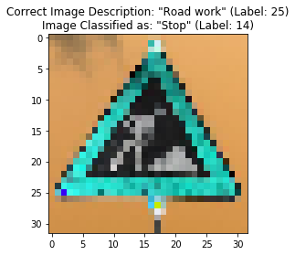

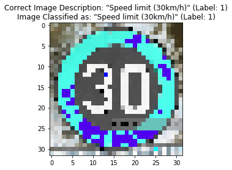

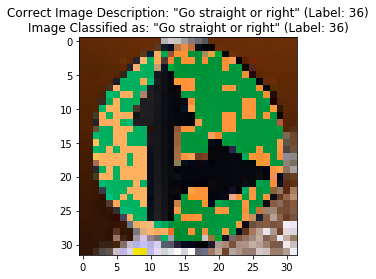

[figure not shown]

[figure not shown]

```python
### Run the predictions here and use the model to output the prediction for each image.
### Make sure to pre-process the images with the same pre-processing pipeline used earlier.
import PIL
from PIL import Image
test_img = np.empty([5, 32, 32, 3])
# Load 5 test images from the "GTSRB" dataset
test_img_name = ('test-images-from-web/test001.jpg',
                 'test-images-from-web/test002.jpg',
                 'test-images-from-web/test003.jpg',
                 'test-images-from-web/test004.jpg',
                 'test-images-from-web/test005.jpg')
# Labels for test data in accordance with signnames.csv
test_label = (25, 1, 36, 38, 39)
# Resize the images to be 32x32 as required by the CNN architecture
for i in range(0, len(test_img_name)):
    img = Image.open(test_img_name[i]);
    test_img[i] = img.resize((32,32))

# Preprocess and Normalize the data
test_img_yuv = preprocessAndNormalize(np.float32(test_img))

#Load the saved model; feed the test images into model to predict the Sign Type
with tf.Session() as sess:
    saver.restore(sess, './saved_sess/traffic_sign_lenet')

    softmax_res = tf.nn.softmax(logits)
    softmax_res = sess.run(softmax_res, feed_dict={x: test_img_yuv})
    classification_label = tf.argmax(softmax_res, 1)
    classification_label = sess.run(classification_label)
    print("\nClassification Result\n")
    for i in range(0, len(test_img_name)):
        test_label_desc = get_label_description(test_label[i])
        plt.figure(i)
        plt.imshow(test_img[i])
        correct_img = 'Correct Image Description: "' + test_label_desc + '" (Label: ' + str(test_label[i]) + ')'
        classified_img = '\nImage Classified as: "' + get_label_description(classification_label[i]) + '" (Label: ' + str(classification_label[i]) + ')'
        plt.title(correct_img + classified_img)
```

### Analyze Performance

```python
### Calculate the accuracy for these 5 new images.
### For example, if the model predicted 1 out of 5 signs correctly, it's 20% accurate on these new images.
with tf.Session() as sess:
    saver.restore(sess, './saved_sess/traffic_sign_lenet')
    test_accuracy = evaluate(test_img_yuv, test_label)
    print("Test Accuracy = {:.3f}%".format(test_accuracy*100))
```

[output not shown]

### Output Top 5 Softmax Probabilities For Each Image Found on the Web

For each of the new images, print out the model's softmax probabilities to show the **certainty** of the model's predictions (limit the output to the top 5 probabilities for each image). [`tf.nn.top_k`](https://www.tensorflow.org/versions/r0.12/api_docs/python/nn.html#top_k) could prove helpful here.

The example below demonstrates how tf.nn.top_k can be used to find the top k predictions for each image.

`tf.nn.top_k` will return the values and indices (class ids) of the top k predictions. So if k=3, for each sign, it'll return the 3 largest probabilities (out of a possible 43) and the correspoding class ids.

Take this numpy array as an example. The values in the array represent predictions. The array contains softmax probabilities for five candidate images with six possible classes. `tf.nn.top_k` is used to choose the three classes with the highest probability:

```
# (5, 6) array
a = np.array([[ 0.24879643,  0.07032244,  0.12641572,  0.34763842,  0.07893497,
         0.12789202],
       [ 0.28086119,  0.27569815,  0.08594638,  0.0178669 ,  0.18063401,
         0.15899337],
       [ 0.26076848,  0.23664738,  0.08020603,  0.07001922,  0.1134371 ,
         0.23892179],
       [ 0.11943333,  0.29198961,  0.02605103,  0.26234032,  0.1351348 ,
         0.16505091],
       [ 0.09561176,  0.34396535,  0.0643941 ,  0.16240774,  0.24206137,
         0.09155967]])
```

Running it through `sess.run(tf.nn.top_k(tf.constant(a), k=3))` produces:

```
TopKV2(values=array([[ 0.34763842,  0.24879643,  0.12789202],
       [ 0.28086119,  0.27569815,  0.18063401],
       [ 0.26076848,  0.23892179,  0.23664738],
       [ 0.29198961,  0.26234032,  0.16505091],
       [ 0.34396535,  0.24206137,  0.16240774]]), indices=array([[3, 0, 5],
       [0, 1, 4],
       [0, 5, 1],
       [1, 3, 5],
       [1, 4, 3]], dtype=int32))
```

Looking just at the first row we get `[ 0.34763842, 0.24879643, 0.12789202]`, you can confirm these are the 3 largest probabilities in `a`. You'll also notice `[3, 0, 5]` are the corresponding indices.

```
INFO:tensorflow:Restoring parameters from ./saved_sess/traffic_sign_lenet
Top 5 Softmax Probabilities For Each Image

TopKV2(values=array([[9.9837780e-01, 1.6220987e-03, 3.7118433e-08, 3.6976047e-08,
        2.9535482e-08],
       [9.9999142e-01, 8.5351785e-06, 1.8879733e-09, 1.5889066e-11,
        2.6207474e-12],
       [1.0000000e+00, 1.3423372e-12, 3.3734927e-14, 7.7994878e-15,
        3.7257456e-20],
       [1.0000000e+00, 3.9625107e-13, 6.9135123e-18, 3.5492674e-18,
        6.0036252e-20],
       [1.0000000e+00, 2.4079580e-25, 1.1236770e-25, 2.6343730e-26,
        3.2016972e-30]], dtype=float32), indices=array([[14, 25, 15,  5, 26],
       [ 1,  2,  3, 29, 15],
       [36, 41, 38, 32, 34],
       [38, 40, 34, 37, 39],
       [39, 33, 37, 40,  2]], dtype=int32))
```

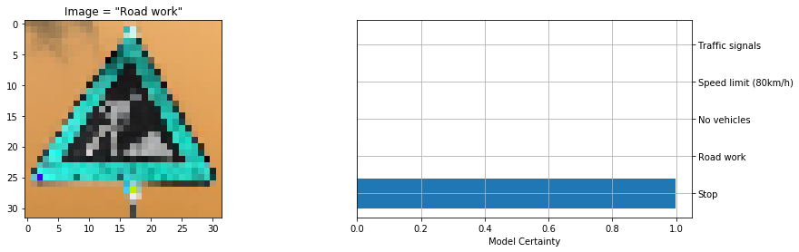

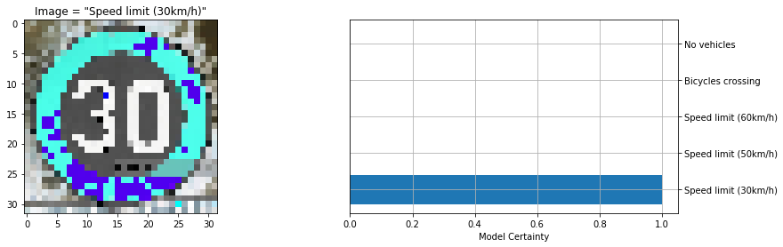

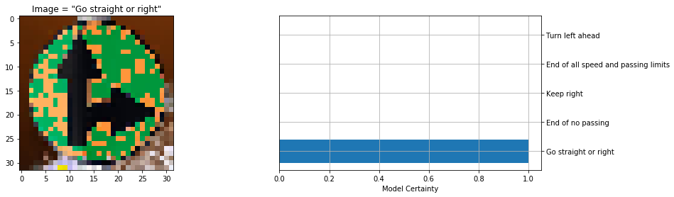

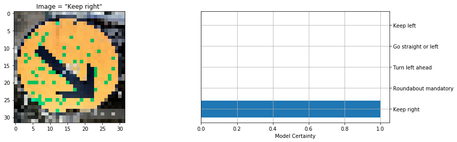

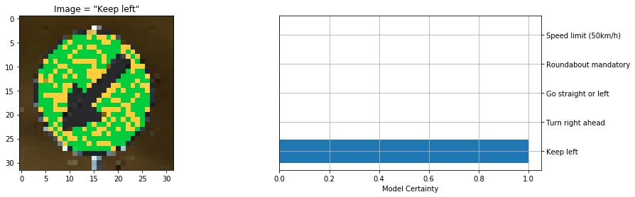

```python
### Print out the top five softmax probabilities for the predictions on the German traffic sign images found on the web.

with tf.Session() as sess:
    saver.restore(sess, './saved_sess/traffic_sign_lenet')
    print("Top 5 Softmax Probabilities For Each Image\n")
    top_k_softmax = sess.run(tf.nn.top_k(softmax_res, k=5))
    print(top_k_softmax)

    for i in range(0, len(test_img_name)):
        test_label_desc = get_label_description(test_label[i])
        f = plt.figure(i)
        ax = f.add_subplot(121)
        plt.imshow(test_img[i])
        plt.title('Image = "' + test_label_desc + '"')
        plt.subplots_adjust(right=2)

        ax = f.add_subplot(122)
        ax.yaxis.tick_right()
        plt.barh(range(0, len(test_img_name)), top_k_softmax.values[i], align='center')
        plt.yticks(range(0, len(test_img_name)), (get_label_description(top_k_softmax.indices[i, 0]),
                                 get_label_description(top_k_softmax.indices[i, 1]),
                                 get_label_description(top_k_softmax.indices[i, 2]),
                                 get_label_description(top_k_softmax.indices[i, 3]),
                                 get_label_description(top_k_softmax.indices[i, 4])))
        plt.xlabel('Model Certainty')
        plt.grid(True)

        plt.show()
```

## Step 4 : Visualize the Neural Network's State with Test Images

As an additional excersise for understaning the output of a neural network's weights. While neural networks can be a great learning device they are often referred to as a black box. We can understand what the weights of a neural network look like better by plotting their feature maps. After successfully training your neural network you can see what it's feature maps look like by plotting the output of the network's weight layers in response to a test stimuli image. From these plotted feature maps, it's possible to see what characteristics of an image the network finds interesting. For a sign, maybe the inner network feature maps react with high activation to the sign's boundary outline or to the contrast in the sign's painted symbol.

Provided for you below is the function code that allows you to get the visualization output of any tensorflow weight layer you want. The inputs to the function should be a stimuli image, one used during training or a new one you provided, and then the tensorflow variable name that represents the layer's state during the training process.

For an example of what feature map outputs look like, check out NVIDIA's results in their paper [End-to-End Deep Learning for Self-Driving Cars](https://devblogs.nvidia.com/parallelforall/deep-learning-self-driving-cars/) in the section Visualization of internal CNN State. NVIDIA was able to show that their network's inner weights had high activations to road boundary lines by comparing feature maps from an image with a clear path to one without.

```
INFO:tensorflow:Restoring parameters from ./saved_sess/traffic_sign_lenet
Layer 1 Feature Maps
```

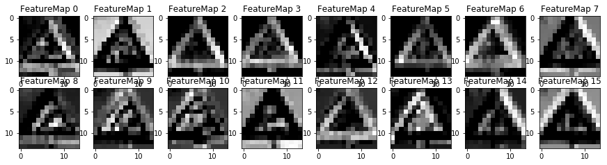

```
Layer 2 Feature Maps
```

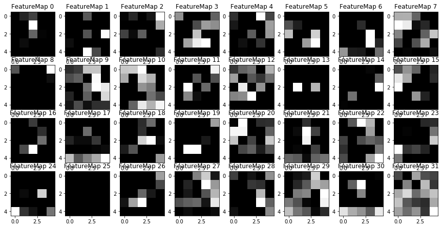

```
Layer 3 Feature Maps
```

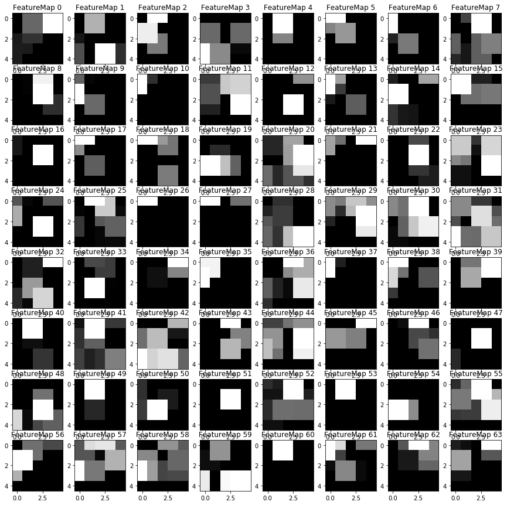

```python
### Visualize your network's feature maps here.

# image_input: the test image being fed into the network to produce the feature maps
# tf_activation: should be a tf variable name used during your training procedure that represents the calculated state of a specific weight layer
# activation_min/max: can be used to view the activation contrast in more detail, by default matplot sets min and max to the actual min and max values of the output
# plt_num: used to plot out multiple different weight feature map sets on the same block, just extend the plt number for each new feature map entry

def outputFeatureMap(sessn, image_input, tf_activation, activation_min=-1, activation_max=-1 ,plt_num=1):
    # Here make sure to preprocess your image_input in a way your network expects
    # with size, normalization, ect if needed
    # image_input =
    # Note: x should be the same name as your network's tensorflow data placeholder variable
    # If you get an error tf_activation is not defined it may be having trouble accessing the variable from inside a function
    activation = tf_activation.eval(session=sessn,feed_dict={x : image_input})
    featuremaps = activation.shape[3]
    plt.figure(plt_num, figsize=(15,15))
    for featuremap in range(featuremaps):
        plt.subplot(8, 8, featuremap+1) # sets the number of feature maps to show on each row and column
        plt.title('FeatureMap ' + str(featuremap)) # displays the feature map number
        if activation_min != -1 & activation_max != -1:
            plt.imshow(activation[0,:,:, featuremap], interpolation="nearest", vmin =activation_min, vmax=activation_max, cmap="gray")
        elif activation_max != -1:
            plt.imshow(activation[0,:,:, featuremap], interpolation="nearest", vmax=activation_max, cmap="gray")
        elif activation_min !=-1:
            plt.imshow(activation[0,:,:, featuremap], interpolation="nearest", vmin=activation_min, cmap="gray")
        else:
            plt.imshow(activation[0,:,:, featuremap], interpolation="nearest", cmap="gray")

with tf.Session() as sess:
    saver.restore(sess, './saved_sess/traffic_sign_lenet')

    plt.figure
    print("Layer 1 Feature Maps")
    outputFeatureMap(sess, test_img_yuv, network_params["conv1"])
    plt.show()

    plt.figure
    print("Layer 2 Feature Maps")
    outputFeatureMap(sess, test_img_yuv, network_params["conv2"])
    plt.show()

    plt.figure
    print("Layer 3 Feature Maps")
    outputFeatureMap(sess, test_img_yuv, network_params["conv3"])
    plt.show()
```